# 1、安装Docker DeskTop

## 1.1 下载安装包

官网 https://www.docker.com/  
按照指示下载安装

## 1.2 设置Proxy

[figure not shown]

## 1.3 设置国内镜像（备选）

[figure not shown]

- 登录 https://cr.console.aliyun.com/cn-hangzhou/instances/mirrors 左侧导航栏选择**镜像工具**->**镜像加速器**  
  然后配置到上面的截图中

# 2、安装Milvus

## 2.1 standalone.bat 方式（不推荐）

新建Milvus文件夹

cd到文件夹

cmd 输入curl -o standalone.bat https://raw.githubusercontent.com/milvus-io/milvus/refs/heads/master/scripts/standalone_embed.bat

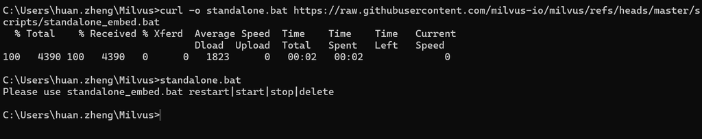

首次输入`standalone.bat start`

有可能docker镜像不对，要调整镜像，下载很慢，需要科学上网

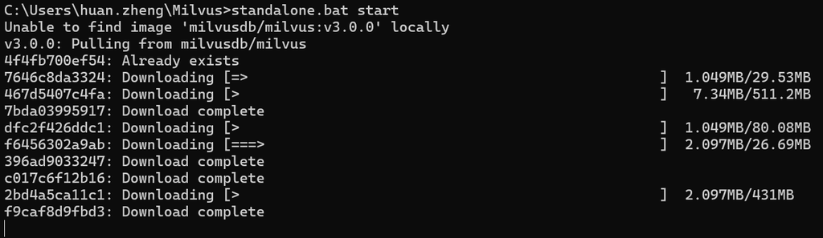

再次启动

输入 `standalone.bat start`

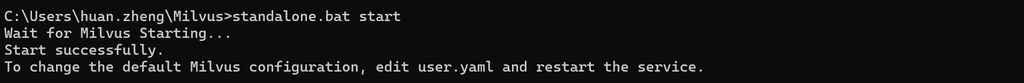

输入 .\standalone.bat stop 停止容器

docker desktop也能操作

## 2.2 docker compose方式

启动 3 个容器：`milvus‑standalone`主程序、`milvus‑etcd`元数据、`milvus‑minio`对象存储Milvus

1、PowerShell 新建一个空文件夹，下载 yml  
输入运行：Invoke-WebRequest https://github.com/milvus-io/milvus/releases/download/v3.0.0/milvus-standalone-docker-compose.yml -OutFile docker-compose.yml

2、启动

docker compose up -d

3、查看状态

docker compose ps

✅正常输出：`milvus‑standalone` 的 PORTS 列显示 `0.0.0.0:19530->19530/tcp, 0.0.0.0:9091->9091/tcp`

4、查看日志（等待服务完全就绪，**需要 60‑90 秒**）  
看到 `server started` 才算 Milvus 服务就绪，不是容器 Running 就可以连。

5、停止 / 销毁

powershell输入运行：

# 停止，保留数据

docker compose stop

# 销毁容器+保留volumes数据

docker compose down

# 销毁容器+删除全部数据

docker compose down -v

> 数据持久化：当前目录`volumes/`下面保存 etcd、minio、milvus 全部数据。  
> 修改配置：复制`milvus.yaml`到本地，在 compose 里挂载；不要直接修改容器内部文件。

校验端口映射（必做） docker port milvus-standalone

> 有输出代表端口映射成功；空白 = 绑定失败，该容器不可用，直接删除重建。

docker desktop上可以看到容器

[figure not shown]

Python 连接测试

# 3、测试前准备工作

## 3.1 确保Milvus已启动

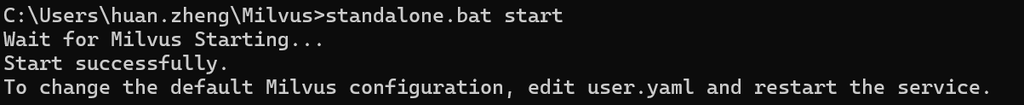

[figure not shown]

## 3.2 安装Milvus Python SDK

`pip install pymilvus`  
Milvus Lite已包含在Milvus的Python SDK中，此处不用Milvus Lite 直接访问在docker desktop安装的、Standalone模式的Milvus服务。

## 3.3 Milvus数据模型

### 3.3.1 整体结构

Milvus数据模型层级： database>collection>partition>entity

- database Milvus的数据库，用来隔离不同业务数据
- collection 最核心的逻辑容器，类似关系型数据库里的table
- partition 分区，是collection的子集，不是必须手动创建，一个collection至少会有默认partition
- entity 可以理解为collection中的一条记录，类似关系型数据库的一行数据。

### 3.3.2 具体说明

向量数据库存储特征向量和对应的文本，为了将不同用途的向量分类别地存放，需要创建不同的collection。  
比如COLLECTION_NAME = "docs",用于存放切分好地文档片段向量

# 4、基本用法

## 4.1 DDL操作

### 4.1.1 Database

#### 1）查看数据库

##### 举例1：操作客户端

```python
from pymilvus import connections
try:
    connections.connect(
        alias="default",
        host="localhost",
        port="19530",
        # user="root", password="xxx" # 开启认证就打开
    )
    print("✅ Milvus连接成功")
    connections.disconnect("default")
except Exception as e:
    print(f"❌连接失败: {e}")
```

```
✅ Milvus连接成功
```

```python
from pymilvus import MilvusClient

client = MilvusClient("http://localhost:19530")
```

##### 举例2：列出所有数据库

```python
existed_databases = client.list_databases()

for db in existed_databases:
    print(db)
```

```
default
```

#### 2）创建新数据库

```python
db_name = "rag_demo"
if db_name not in existed_databases:
    client.create_database(db_name=db_name)
```

#### 3）删除数据库

**如果数据库下有Collection则无法删除，需要先删除它所有的Collection才能删除Database**

```python
client.drop_database(db_name=db_name)
```

### 4.1.2 Collection相关操作

#### 1）切换数据库

```python
client.use_database(db_name=db_name)
```

#### 2）查看数据库下的Collections

```python
collections = client.list_collections()

for coll in collections:
    print(coll)
```

#### 3）创建colllection

```python
collection_name = "docs"

client.create_collection(
    collection_name=collection_name,
    dimension=1024,  # 和向量化时嵌入模型一致
    metric_type="COSINE"
)
```

#### 4）删除collection

```python
client.drop_collection(collection_name=collection_name)
```

## 4.2 DML操作

### 4.2.1 嵌入模型初始化

```python
import os
from langchain_openai import OpenAIEmbeddings
from dotenv import load_dotenv

load_dotenv()
# =========================
# 3. 初始化 Embedding 模型
# =========================
embed_model = OpenAIEmbeddings(
    model="Pro/BAAI/bge-m3",
    openai_api_base=os.environ["SILICON_BASE_URL"],
    openai_api_key=os.environ["SILICON_API_KEY"],
    # dimensions=1024, # 可保留；最关键的是 collection 要按 1024 建
)
```

bge-m3 是固定 1024 维的模型，SiliconFlow 的接口不接受 dimensions 这个参数

### 4.2.2 准备collection

#### 1）创建collection

```python
client.drop_collection(collection_name="docs0826")
```

```python
collection_name = "docs0825"

client.create_collection(
    collection_name=collection_name,
    dimension=1024,   # 要和嵌入模型的demensions一致
    metric_type="COSINE"
)
```

#### 2）查看collection元数据

```python
from  rich import print as rprint
metdata = client.describe_collection(collection_name=collection_name)

rprint(metdata)
```

```
{
    'collection_name': 'docs0825',
    'auto_id': False,
    'num_shards': 1,
    'description': '',
    'fields': [
        {
            'field_id': 100,
            'name': 'id',
            'description': '',
            'type': <DataType.INT64: 5>,
            'params': {},
            'is_primary': True
        },
        {
            'field_id': 101,
            'name': 'vector',
            'description': '',
            'type': <DataType.FLOAT_VECTOR: 101>,
            'params': {'dim': 1024}
        }
    ],
    'functions': [],
    'aliases': [],
    'collection_id': 468638891251865452,
    'consistency_level': 2,
    'consistency_level_name': 'Bounded',
    'properties': {'timezone': 'UTC', 'namespace.sharding.enabled': 'false', 'max_field_id': '102'},
    'num_partitions': 1,
    'enable_dynamic_field': True,
    'enable_namespace': False,
    'schema_version': 0,
    'created_timestamp': 468639143640694803,
    'update_timestamp': 468639143640694803
}
```

### 4.2.3 准备数据

#### 1）准备原始数据

```python
texts = [
    "database    Milvus的数据库，用来隔离不同业务数据",
    "collection   最核心的逻辑容器，类似关系型数据库里的table",
    "partition   分区，是collection的子集，不是必须手动创建，一个collection至少会有默认partition",
    "entity   可以理解为collection中的一条记录，类似关系型数据库的一行数据。"
]
```

#### 2）生成嵌入向量

```python
vectors = embed_model.embed_documents(texts)
```

嵌入模型不能写dimensions 这个参数，否则会报错

#### 3）查看生成的嵌入向量

```python
print(len(vectors))

print(len(vectors[0]))

print(vectors[0][:5])
```

```
4
1024
[-0.019505193457007408, 0.030341412872076035, -0.03421149030327797, -0.01780235953629017, -0.012152045033872128]
```

#### 4）封装为可以插入的数据格式

```python
data = [
    {
        "id" : i,
        "vector" : vectors[i],
        "text" : texts[i],
        "source" : "demo"
    } for i in range(len(texts))
]
```

### 4.2.4 写入数据

#### 1）写入数据

```python
insert_res = client.upsert(
    collection_name=collection_name,
    data=data,
)

print("insert result :",insert_res)
```

```
insert result : {'upsert_count': 4, 'ids': [0, 1, 2, 3]}
```

#### 2）手动flush

Milvus 不会第一时间将数据落盘，要看写入效果，我们手动flush，将数据刷写到磁盘

```python
client.flush(collection_name=collection_name)
```

#### 3）查看collection统计信息

```python
stats = client.get_collection_stats(collection_name=collection_name)
print(stats)
```

```
{'row_count': 4}
```

# 3、DQL操作

## 3.1 扫描数据

```python
iterator = client.query_iterator(
    collection_name=collection_name,
    filter="",
    output_fields=["*"]
)

i=0
while True:
    rows = iterator.next()

    if not rows:
        break
    for row in rows:
        print(f"第{i + 1}条数据")
        # print(row)

        print(f"id = {row['id']}, vector = {row['vector'][:5]}, text = {row['text']}, source = {row['source']}")
        i +=1

iterator.close()
```

```
第1条数据
id = 0, vector = [-0.019505193457007408, 0.030341412872076035, -0.03421149030327797, -0.01780235953629017, -0.012152045033872128], text = database    Milvus的数据库，用来隔离不同业务数据, source = demo
第2条数据
id = 1, vector = [-0.0023934897035360336, 0.010630395263433456, 0.032089270651340485, 0.004786979407072067, 0.043049801141023636], text = collection   最核心的逻辑容器，类似关系型数据库里的table, source = demo
第3条数据
id = 2, vector = [-0.011202643625438213, 0.036571212112903595, 0.0006369245238602161, -0.017851954326033592, 0.00404740683734417], text = partition   分区，是collection的子集，不是必须手动创建，一个collection至少会有默认partition, source = demo
第4条数据
id = 3, vector = [0.012002291157841682, 0.05517936497926712, -0.018782805651426315, -0.009897992946207523, 0.018782805651426315], text = entity   可以理解为collection中的一条记录，类似关系型数据库的一行数据。, source = demo
```

## 3.2 通过主键查询数据

```python
res = client.get(
    collection_name=collection_name,
    ids=[0,1,2]
)
print(len(res))

for i in range(len(res)):
    print(f"第{i+1}条数据：")
    print(f"id = {res[i]['id']}, vector = {res[i]['vector'][:5]}, text = {res[i]['text']}, source = {res[i]['source']}")
```

```
3
第1条数据：
id = 0, vector = [-0.019505193457007408, 0.030341412872076035, -0.03421149030327797, -0.01780235953629017, -0.012152045033872128], text = database    Milvus的数据库，用来隔离不同业务数据, source = demo
第2条数据：
id = 1, vector = [-0.0023934897035360336, 0.010630395263433456, 0.032089270651340485, 0.004786979407072067, 0.043049801141023636], text = collection   最核心的逻辑容器，类似关系型数据库里的table, source = demo
第3条数据：
id = 2, vector = [-0.011202643625438213, 0.036571212112903595, 0.0006369245238602161, -0.017851954326033592, 0.00404740683734417], text = partition   分区，是collection的子集，不是必须手动创建，一个collection至少会有默认partition, source = demo
```

## 3.3 相似度检索

### 1）准备查询嵌入

```python
query = "什么是collection？"
query_vector = embed_model.embed_query(query)
```

### 2）检索

```python
results = client.search(
    collection_name=collection_name,
    data=[query_vector],
    limit=3,
    output_fields=["text","source",'id']
)

for res in results[0]:
    print(res)
```

```
{'id': 2, 'distance': 0.6808801889419556, 'entity': {'id': 2, 'text': 'partition   分区，是collection的子集，不是必须手动创建，一个collection至少会有默认partition', 'source': 'demo'}}
{'id': 1, 'distance': 0.6578744649887085, 'entity': {'id': 1, 'text': 'collection   最核心的逻辑容器，类似关系型数据库里的table', 'source': 'demo'}}
{'id': 3, 'distance': 0.2471303641796112, 'entity': {'id': 3, 'text': 'entity   可以理解为collection中的一条记录，类似关系型数据库的一行数据。', 'source': 'demo'}}
```